# FinalIndividualHW

Jack Keaveny

2024-12-21

## Loading In and Understanding our Data

```r
# Loading in our data
hr_data <- read.csv("C:/Users/Jack Keaveny/Downloads/HRDataset_v14.csv")
```

```r
# Looking at variable summary statistics and checking for NA values
summary(hr_data, results = FALSE)

colSums(is.na(hr_data))
```

[output not shown]

I found that there are 8 NA values for 311 total observations under ManagerID for this data set. Upon going through and looking at these NA values myself, it appears that they could be cleaned up for further cohesiveness in our data set and more accurate results. All of the rows with NA values have the manager ‘Webster Butler’ who has the ManagerID of 39. Therefore, we’re going to fill in the missing values with 39.

```r
# Replacing NA values with 39
hr_data$ManagerID[is.na(hr_data$ManagerID)] <- 39

sum(is.na(hr_data$ManagerID))
```

```
## [1] 0
```

## Questions

I’m going to be answering some of the provided example questions, as well as a few of my own through a number of different techniques including simple visual/descriptive analysis, PCA analysis, and cluster analysis.

### 1. Is there any correlation between who an employee works for and their performance score?

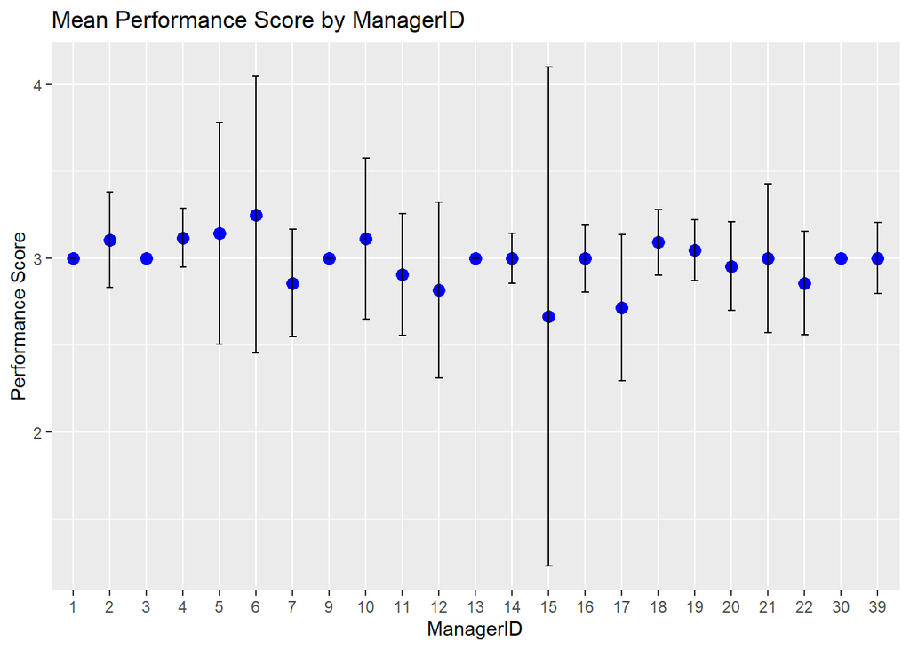

```r
# Creating a point plot of the mean performance scores for each manager

ggplot(hr_data, aes(x = as.factor(ManagerID), y = PerfScoreID)) +
  stat_summary(fun = mean, geom = "point", color = "blue", size = 3) +
  stat_summary(fun.data = mean_cl_normal, geom = "errorbar", width = 0.2) +
  labs(title = "Mean Performance Score by ManagerID", x = "ManagerID", y = "Performance Score")
```

```r
# Counting the number of ManagerId = 15 observations
sum(hr_data$ManagerID == 15, na.rm = TRUE)
```

```
## [1] 3
```

As we can see, there is no drastic difference in performance between most of the managers. It is notable that ManagerID 15 appears to have a wider variance in outcomes, but this is merely to account for the fact that this ManagerId only shows up three times in our data set.

### 2. What is the overall diversity profile of the data set?

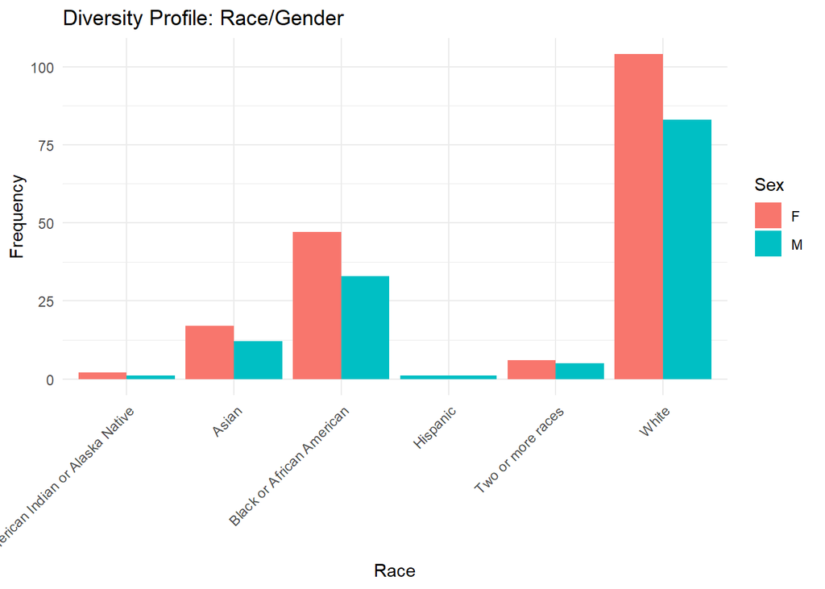

```r
# Bar plot to show our race/gender demographic makeup
ggplot(hr_data, aes(x = RaceDesc, fill = Sex)) +
  geom_bar(position = "dodge") +
  labs(title = "Diversity Profile: Race/Gender", x = "Race", y = "Frequency") +
  theme_minimal() +
  theme(axis.text.x = element_text(angle = 45, hjust = 1))
```

Here we can see the demographic makeup of the company. White men and women make up the vast majority of the employees, with Black/African American men and women behind. There are far more women at the company than there are men as well. Let’s do a quick cluster analysis to further understand the kinds of employees working at the company, now including marital status as well. Given the small size of the data set, we’ll be performing hierachical clustering with a dendrogram.

```r
# Cleaning/encoding HispanicLatino
hr_data$HispanicLatino <- tolower(hr_data$HispanicLatino)
hr_data$HispanicLatino <- ifelse(hr_data$HispanicLatino == "yes", 1, 0)

# Encoding dummy variables for RaceDesc
hr_data <- dummy_cols(hr_data, select_columns = "RaceDesc", remove_first_dummy = TRUE)

# Subsetting our diversity-related variables (including MaritalStatusID)
diversity_data <- hr_data[, c("GenderID", "HispanicLatino", "MaritalStatusID", grep("RaceDesc_", colnames(hr_data), value = TRUE))]

# Scaling data
diversity_data_scaled <- scale(diversity_data)
```

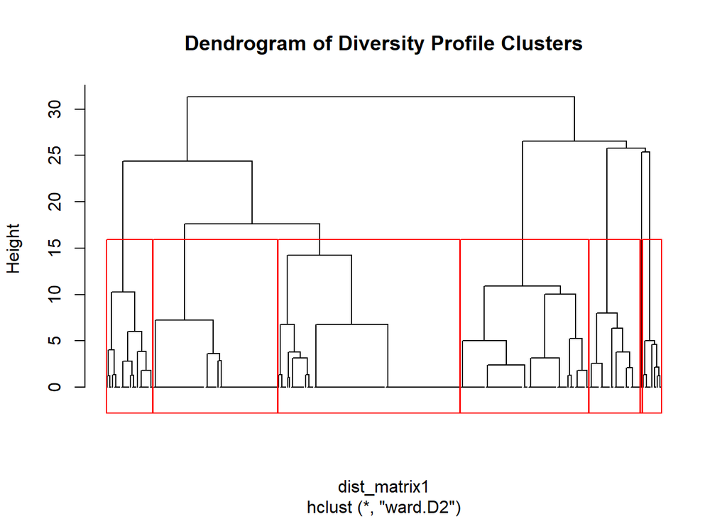

```r
# Computing the distance matrix
dist_matrix1 <- dist(diversity_data_scaled, method = "euclidean")

# Hierarchical clustering (Ward's method proved to be easier to interpret)
hclust_result1 <- hclust(dist_matrix1, method = "ward.D2")

# Visualizing the dendrogram (k=7 aligns best with the visual results)
plot(hclust_result1, labels = FALSE, hang = -1, main = "Dendrogram of Diversity Profile Clusters")
rect.hclust(hclust_result1, k = 7, border = "red")
```

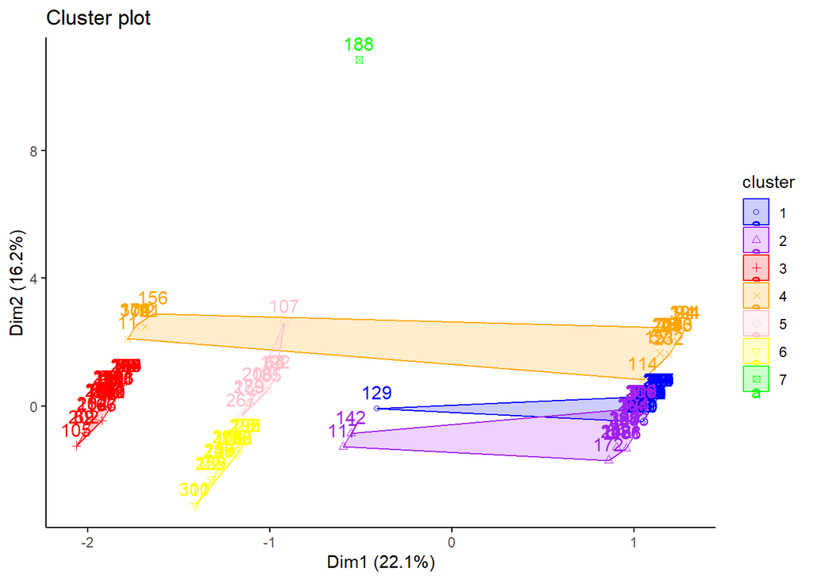

```r
# Assigning clusters
clusters <- cutree(hclust_result1, k = 7)
hr_data$Cluster <- as.factor(clusters)

# Visualizing diversity clusters
fviz_cluster(list(data = diversity_data_scaled, cluster = clusters),
             palette = c('blue', 'purple', 'red', 'orange', 'pink', 'yellow', 'green'),
             ellipse.type = "convex",
             repel = F,
             show.clust.cent = FALSE,
             ggtheme = theme_classic())
```

```r
# Understanding how our clusters are separated/made
cluster_summary <- aggregate(diversity_data, by = list(Cluster = hr_data$Cluster), mean)
print(cluster_summary)
```

```
##   Cluster   GenderID HispanicLatino MaritalStatusID RaceDesc_Asian
## 1       1 1.00000000     0.00000000       0.6857143              0
## 2       2 0.04901961     0.00000000       0.9411765              0
## 3       3 0.41666667     0.00000000       0.8888889              0
## 4       4 0.46153846     1.00000000       0.5000000              0
## 5       5 0.45454545     0.09090909       0.4545455              0
## 6       6 0.41379310     0.00000000       0.8965517              1
## 7       7 1.00000000     1.00000000       0.0000000              0
##   RaceDesc_Black or African American RaceDesc_Hispanic
## 1                          0.0000000                 0
## 2                          0.0000000                 0
## 3                          1.0000000                 0
## 4                          0.3076923                 0
## 5                          0.0000000                 0
## 6                          0.0000000                 0
## 7                          0.0000000                 1
##   RaceDesc_Two or more races RaceDesc_White
## 1                          0      0.9857143
## 2                          0      0.9803922
## 3                          0      0.0000000
## 4                          0      0.6923077
## 5                          1      0.0000000
## 6                          0      0.0000000
## 7                          0      0.0000000
```

```r
#PCA to understand the proportions of variance explained by first few dimensions
pca_result <- prcomp(diversity_data_scaled)
summary(pca_result)
```

```
## Importance of components:
##                           PC1    PC2    PC3    PC4    PC5    PC6     PC7
## Standard deviation     1.3305 1.1388 1.0765 1.0321 0.9923 0.9604 0.88595
## Proportion of Variance 0.2213 0.1621 0.1449 0.1332 0.1231 0.1153 0.09811
## Cumulative Proportion  0.2213 0.3834 0.5282 0.6614 0.7845 0.8998 0.99788
##                            PC8
## Standard deviation     0.13030
## Proportion of Variance 0.00212
## Cumulative Proportion  1.00000
```

### 3. What are our best recruiting sources if we want to ensure a diverse organization?

Now that we’ve seen our demographic makeup, it’s now time to ask how we can make the company more diverse. Having a more diverse workplace will make everyone feel more welcome, and a myriad of different backgrounds and experiences is beneficial for both company culture and the emergence of new ideas.

As we’ve seen, white men and women make up the vast majority of the company, so we’ll be focusing our efforts to recruit more people of Black, Asian, Hispanic, and American Indian/Alaskan descent.

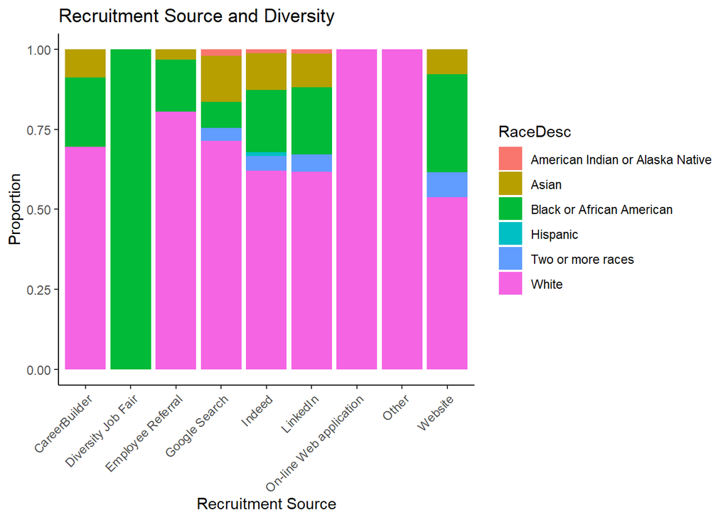

```r
# Grouped bar chart for race by recruitment source
ggplot(hr_data, aes(x = RecruitmentSource, fill = RaceDesc)) +
  geom_bar(position = "fill") +
  labs(title = "Recruitment Source and Diversity", x = "Recruitment Source", y = "Proportion") +
  theme_classic() +
  theme(axis.text.x = element_text(angle = 45, hjust = 1))
```

### 4. Can we predict who is going to terminate and who isn’t? What level of accuracy can we achieve on this?

In order to answer this question, I’m going to build a random forest classification model to predict whether or not an employee will be fired. Termd will be our target variable, and I’m only going to use numeric variables for our predictors. Given that companies are not allowed to terminate indivudals based on race or gender, it will be interesting to see our results.

```r
# Selecting numeric columns only
numeric_data <- hr_data[, sapply(hr_data, is.numeric)]

# Remove unimportant/irrelevant variables from the numeric dataset
numeric_data <- numeric_data %>%
  select(-EmpStatusID, -EmpID, -ManagerID, -DeptID, -Zip)

# Ensuring Termd is in the data and set as a factor (for classification)
numeric_data$Termd <- as.factor(hr_data$Termd)

# Creating our split (0.8 was found to maximize accuracy while still keeping a decent number of testing observations)
data_split <- initial_split(numeric_data, prop = 0.8, strata = Termd)
train_data <- training(data_split)
test_data <- testing(data_split)

# Initializing our recipe
rf_recipe <- recipe(Termd ~ ., data = train_data) %>%
  step_normalize(all_numeric_predictors())

# Model creation
rf_spec <- rand_forest(mtry = tune(), trees = 500, min_n = tune()) %>%
  set_engine("ranger", importance = "impurity") %>%
  set_mode("classification")

# Workflow creation
rf_workflow <- workflow() %>%
  add_recipe(rf_recipe) %>%
  add_model(rf_spec)

# Creating our folds and setting seed for reproducibility
set.seed(42)
cv_folds <- vfold_cv(train_data, v = 5)

# Tuning our model
rf_tune_results <- tune_grid(
  rf_workflow,
  resamples = cv_folds,
  grid = 10,  # Number of tuning grid combinations
  metrics = metric_set(roc_auc, accuracy)
)

# Selecting the best hyperparameters to achieve best accuracy
best_params <- select_best(rf_tune_results, metric = "accuracy")

# Finalizing our workflow
final_rf_workflow <- finalize_workflow(rf_workflow, best_params)
final_rf_fit <- fit(final_rf_workflow, data = train_data)
```

```r
# Predictions for probabilities and classes
rf_predictions <- predict(final_rf_fit, new_data = test_data, type = "prob") %>%
  bind_cols(predict(final_rf_fit, new_data = test_data, type = "class")) %>%
  bind_cols(test_data)

# Confusion matrix
conf_mat <- conf_mat(rf_predictions, truth = Termd, estimate = .pred_class)
print(conf_mat)
```

```
##           Truth
## Prediction  0  1
##          0 41 20
##          1  1  1
```

```r
# Metrics (accuracy, roc_auc, precision, recall, f1)
metrics_results <- rf_predictions %>%
  yardstick::metrics(truth = Termd, estimate = .pred_class, .pred_1)

precision <- precision(rf_predictions, truth = Termd, estimate = .pred_class)
recall <- recall(rf_predictions, truth = Termd, estimate = .pred_class)
f1_score <- f_meas(rf_predictions, truth = Termd, estimate = .pred_class)

# Printing out various classification metrics
cat("Accuracy:", metrics_results %>% filter(.metric == "accuracy") %>% pull(.estimate), "\n")
```

```
## Accuracy: 0.6666667
```

```r
cat("ROC AUC:", metrics_results %>% filter(.metric == "roc_auc") %>% pull(.estimate), "\n")
```

```
## ROC AUC: 0.3752834
```

```r
cat("Precision:", precision %>% pull(.estimate), "\n")
```

```
## Precision: 0.6721311
```

```r
cat("Recall:", recall %>% pull(.estimate), "\n")
```

```
## Recall: 0.9761905
```

```r
cat("F1 Score:", f1_score %>% pull(.estimate), "\n")
```

```
## F1 Score: 0.7961165
```

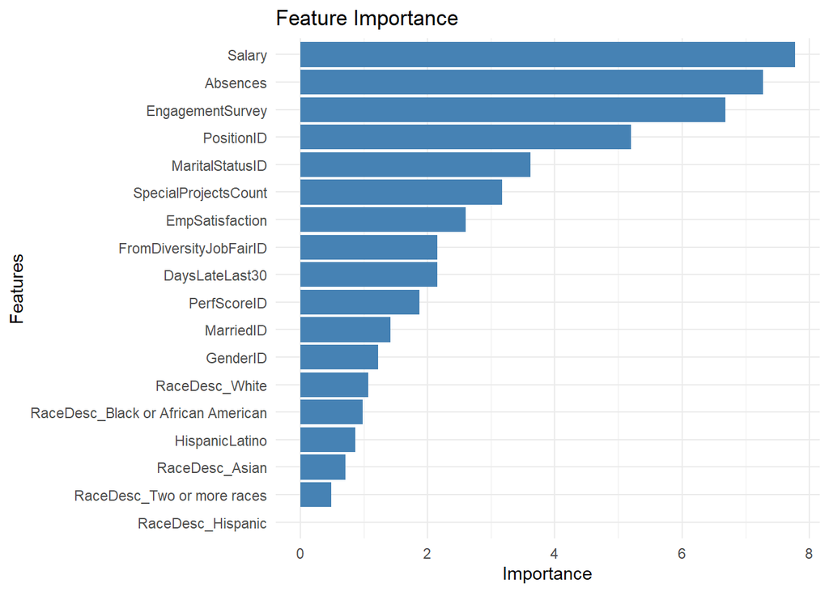

```r
# Refitting the model with feature importance enabled
rf_spec <- rand_forest(mtry = tune(), trees = 500, min_n = tune()) %>%
  set_engine("ranger", importance = "impurity") %>%
  set_mode("classification")

# Finalizing our workflow and fitting the model to training data
final_rf_fit <- finalize_workflow(rf_workflow, best_params) %>%
  fit(data = train_data)

# Extracting feature importance
importance <- final_rf_fit %>%
  extract_fit_parsnip() %>%
  vip::vi()

# Plotting feature importance
library(ggplot2)
ggplot(importance, aes(x = reorder(Variable, Importance), y = Importance)) +
  geom_bar(stat = "identity", fill = "steelblue") +
  coord_flip() +
  labs(title = "Feature Importance",
       x = "Features",
       y = "Importance") +
  theme_minimal()
```

### 5. Are there areas of the company where the pay is not equitable?

Let’s look at some salary trends for various groups within the company. Once again, we’ll be going back to our previously created clusters to see if there is any major difference between those groups.

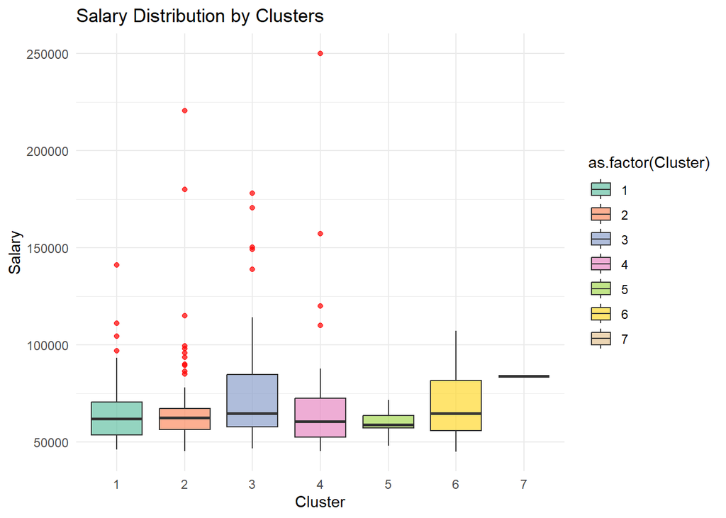

```r
# Boxplot for salary by diversity cluster
ggplot(hr_data, aes(x = as.factor(Cluster), y = Salary, fill = as.factor(Cluster))) +
  geom_boxplot(outlier.colour = "red", alpha = 0.7) +
  scale_fill_brewer(palette = "Set2") +
  labs(title = "Salary Distribution by Clusters",
       x = "Cluster",
       y = "Salary") +
  theme_minimal()
```

Based on this graphic, there does not appear to be any major salary difference based on our diversity clusters that we previously created, meaning that the company is not biasing any one race/gender/marital status when it comes to pay.

Now, let’s see if salary varies by department.

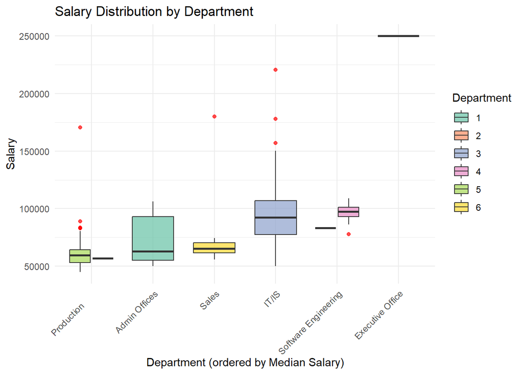

```r
# Boxplot for salary by department
ggplot(hr_data, aes(x = reorder(Department, Salary, FUN = median), y = Salary, fill = as.factor(DeptID))) +
  geom_boxplot(outlier.color = "red", alpha = 0.7) +
  scale_fill_brewer(palette = "Set2") +
  labs(title = "Salary Distribution by Department",
       x = "Department (ordered by Median Salary)",
       y = "Salary",
       fill = "Department") +
  theme_minimal() +
  theme(axis.text.x = element_text(angle = 45, hjust = 1))
```

As we can see here, the median salaries for production team members tend to be the lowest, while the IT and Software Engineering departments get paid more. Executive office members make far more money than the rest of the company, but this is to be expected for upper management positions.

### Question 6: What factors contribute most to employee morale?

Using EmpSatisfaction, I want to look at which factors correlate the highest with employee morale so that the company can understand how to better keep a positive workplace environment.

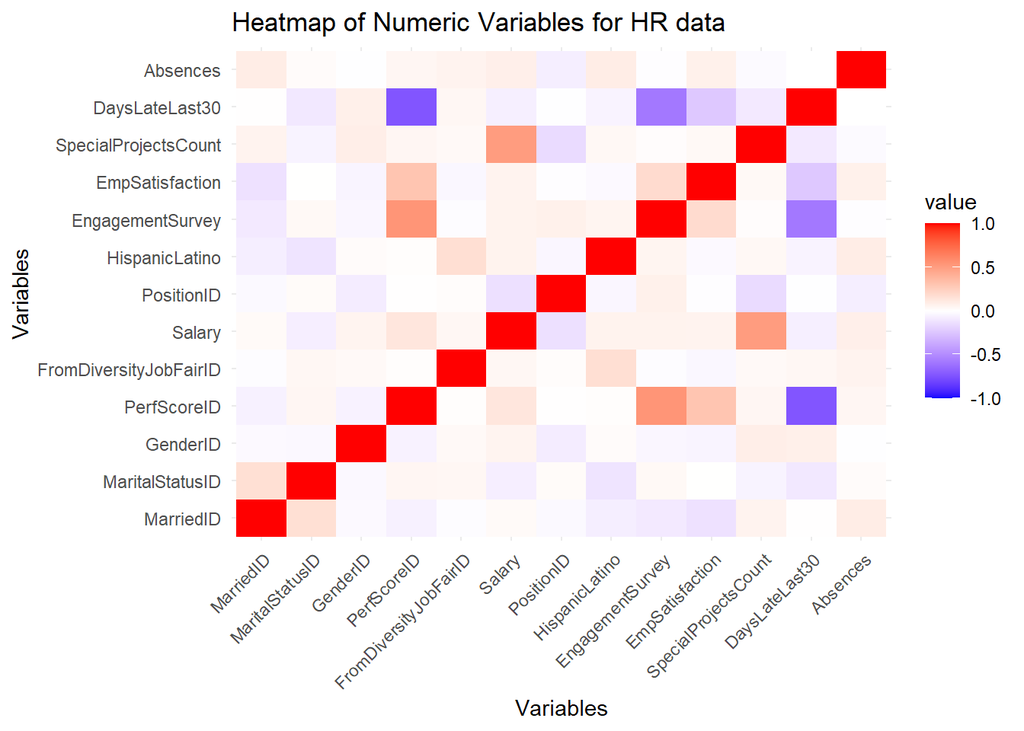

```r
# Select numeric columns and exclude irrelevant ones
numeric_subset <- numeric_data %>%
  select(-Termd, -contains("RaceDesc_"))

# Computing correlation matrix
cor_matrix <- cor(numeric_subset, use = "complete.obs")

#Reshaping the correlation matrix to plot easier
correlation_data <- melt(cor_matrix)

# Heatmap of correlations for numeric relevant variables
ggplot(correlation_data, aes(Var1, Var2, fill = value)) +
  geom_tile() +
  scale_fill_gradient2(low = "blue", high = "red", mid = "white", midpoint = 0, limit = c(-1, 1)) +
  theme_minimal() +
  labs(title = "Heatmap of Numeric Variables for HR data",
       x = "Variables", y = "Variables") +
  theme(axis.text.x = element_text(angle = 45, hjust = 1))
```

It appears that there is not much correlation between EmpSatisfaction and other variables as I previously thought. We can see that PerfScoreId and EngagementSurvey are relatively strongly correlated with satisfaction, and DaysLateLast30 is relatively strongly negatively correlated. Overall, it seems that simply more engaged and focused employees tend to be happier and more satisfied with their work. I expected salary to have a decent amount of correlation, but it actually has very little.

### Question 7: How are performance scores affected by an employee’s number of special projects?

I noticed in our last question’s heatmap that salary and number of special projects are highly correlated, so I’d like to look further into the special projects variable. The more special projects an employee has, it is possible that they could become overworked and their performance could take a dip. Let’s look at the relationship between special project count and performance score.

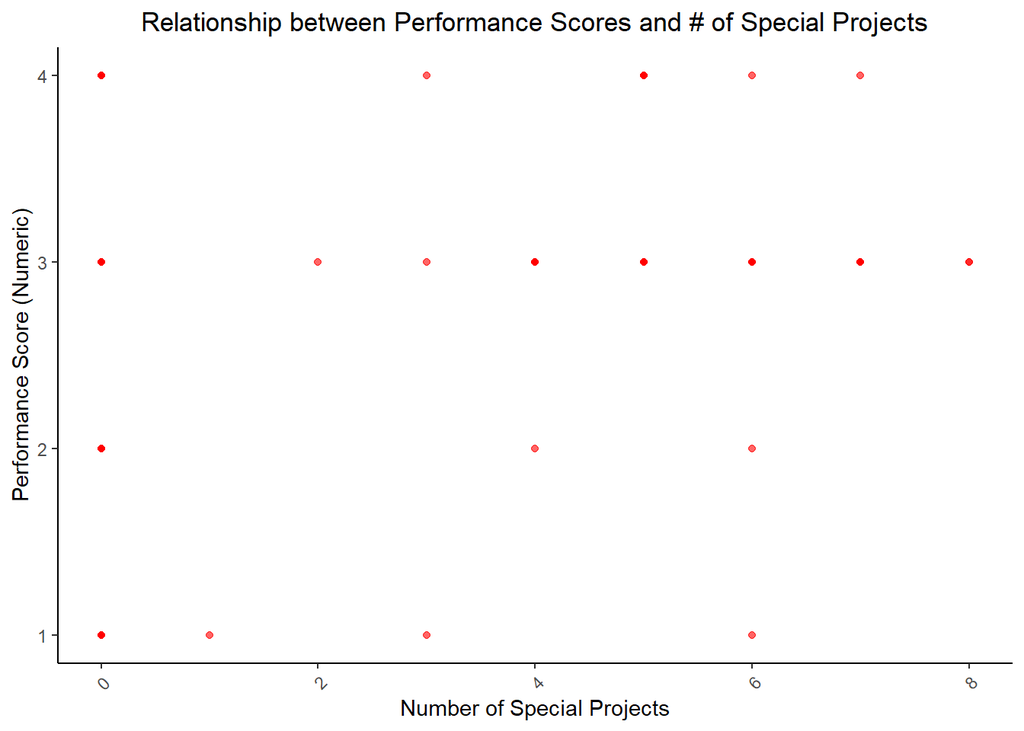

```r
# Scatter plotting of performance score vs. special projects count
ggplot(hr_data, aes(x = SpecialProjectsCount, y = as.numeric(PerfScoreID))) +
  geom_point(color = 'red', alpha = 0.6) +
  labs(
    title = "Relationship between Performance Scores and # of Special Projects",
    x = "Number of Special Projects",
    y = "Performance Score (Numeric)"
  ) +
  theme_classic() +
  theme(
    plot.title = element_text(hjust = 0.5),
    axis.text.x = element_text(angle = 45, hjust = 1)
  )
```

### 8. Do certain recruitment sources attract better-performing employees?

```r
library(caret)

# Selecting variables for PCA
pca_data <- hr_data %>%
  select(PerfScoreID, EmpSatisfaction, EngagementSurvey, Absences, DaysLateLast30) %>%
  mutate(PerfScoreID = as.numeric(PerfScoreID))


# Scaling our data to prepare for PCA
pca_data_scaled <- scale(pca_data)

# Applying PCA
pca_result <- prcomp(pca_data_scaled, center = TRUE, scale. = TRUE)
summary(pca_result)
```

```
## Importance of components:
##                           PC1    PC2    PC3     PC4     PC5
## Standard deviation     1.5420 1.0163 0.9209 0.69501 0.50821
## Proportion of Variance 0.4755 0.2066 0.1696 0.09661 0.05166
## Cumulative Proportion  0.4755 0.6821 0.8517 0.94834 1.00000
```

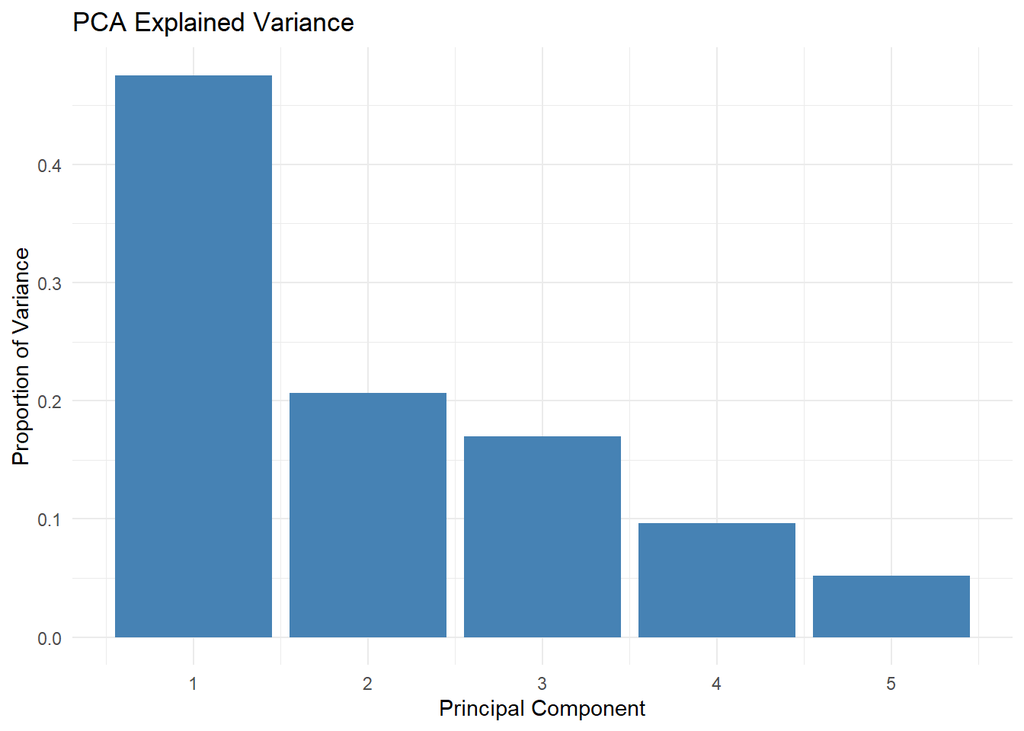

```r
# Barplot the explained variance
explained_variance <- data.frame(
  PC = 1:length(pca_result$sdev),
  Variance = pca_result$sdev^2 / sum(pca_result$sdev^2)
)

ggplot(explained_variance, aes(x = PC, y = Variance)) +
  geom_bar(stat = "identity", fill = "steelblue") +
  labs(title = "PCA Explained Variance", x = "Principal Component", y = "Proportion of Variance") +
  theme_minimal()
```

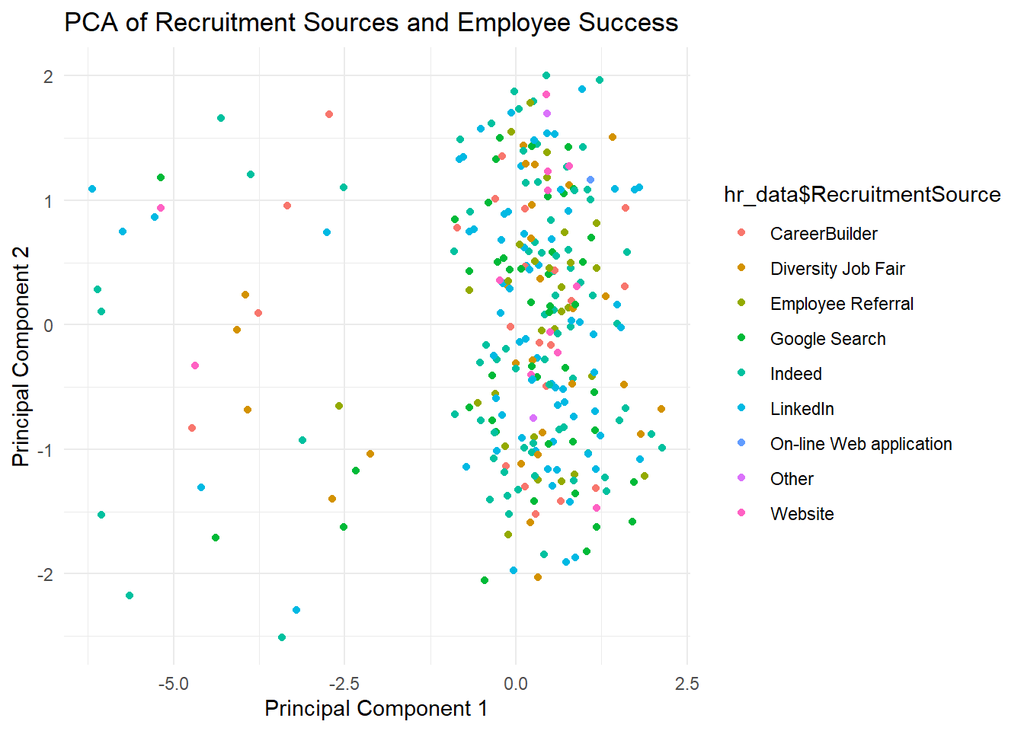

```r
pca_data_with_components <- as.data.frame(pca_result$x)

# Plotting the relationship between our first two components and hiring source
ggplot(pca_data_with_components, aes(PC1, PC2, color = hr_data$RecruitmentSource)) +
  geom_point() +
  labs(title = "PCA of Recruitment Sources and Employee Success",
       x = "Principal Component 1", y = "Principal Component 2") +
  theme_minimal()
```

Thank you for reading my analysis!